# Risk Factor Analysis

## Outcome Variable

**Outcome Variable:** ever_swasted

## Predictor Variables

**Intervention Variable:** gagebrth

**Adjustment Set:**

unadjusted

## Stratifying Variables

The analysis was stratified on these variable(s):

- agecat
- studyid
- country

## Data Summary

| agecat | studyid | country | gagebrth | ever_swasted | n_cell | n |
| --- | --- | --- | --- | --- | --- | --- |
| 0-24 months (no birth wast) | CMC-V-BCS-2002 | INDIA | Full or late term | 0 | 183 | 348 |
| 0-24 months (no birth wast) | CMC-V-BCS-2002 | INDIA | Full or late term | 1 | 30 | 348 |
| 0-24 months (no birth wast) | CMC-V-BCS-2002 | INDIA | Preterm | 0 | 42 | 348 |
| 0-24 months (no birth wast) | CMC-V-BCS-2002 | INDIA | Preterm | 1 | 10 | 348 |
| 0-24 months (no birth wast) | CMC-V-BCS-2002 | INDIA | Early term | 0 | 71 | 348 |
| 0-24 months (no birth wast) | CMC-V-BCS-2002 | INDIA | Early term | 1 | 12 | 348 |
| 0-24 months (no birth wast) | COHORTS | GUATEMALA | Full or late term | 0 | 441 | 809 |
| 0-24 months (no birth wast) | COHORTS | GUATEMALA | Full or late term | 1 | 7 | 809 |
| 0-24 months (no birth wast) | COHORTS | GUATEMALA | Preterm | 0 | 126 | 809 |
| 0-24 months (no birth wast) | COHORTS | GUATEMALA | Preterm | 1 | 4 | 809 |
| 0-24 months (no birth wast) | COHORTS | GUATEMALA | Early term | 0 | 222 | 809 |
| 0-24 months (no birth wast) | COHORTS | GUATEMALA | Early term | 1 | 9 | 809 |
| 0-24 months (no birth wast) | COHORTS | INDIA | Full or late term | 0 | 556 | 1345 |
| 0-24 months (no birth wast) | COHORTS | INDIA | Full or late term | 1 | 23 | 1345 |
| 0-24 months (no birth wast) | COHORTS | INDIA | Preterm | 0 | 294 | 1345 |
| 0-24 months (no birth wast) | COHORTS | INDIA | Preterm | 1 | 14 | 1345 |
| 0-24 months (no birth wast) | COHORTS | INDIA | Early term | 0 | 433 | 1345 |
| 0-24 months (no birth wast) | COHORTS | INDIA | Early term | 1 | 25 | 1345 |
| 0-24 months (no birth wast) | COHORTS | PHILIPPINES | Full or late term | 0 | 1073 | 2993 |
| 0-24 months (no birth wast) | COHORTS | PHILIPPINES | Full or late term | 1 | 85 | 2993 |
| 0-24 months (no birth wast) | COHORTS | PHILIPPINES | Preterm | 0 | 581 | 2993 |
| 0-24 months (no birth wast) | COHORTS | PHILIPPINES | Preterm | 1 | 52 | 2993 |
| 0-24 months (no birth wast) | COHORTS | PHILIPPINES | Early term | 0 | 1093 | 2993 |
| 0-24 months (no birth wast) | COHORTS | PHILIPPINES | Early term | 1 | 109 | 2993 |
| 0-24 months (no birth wast) | IRC | INDIA | Full or late term | 0 | 206 | 389 |
| 0-24 months (no birth wast) | IRC | INDIA | Full or late term | 1 | 43 | 389 |
| 0-24 months (no birth wast) | IRC | INDIA | Preterm | 0 | 34 | 389 |
| 0-24 months (no birth wast) | IRC | INDIA | Preterm | 1 | 8 | 389 |
| 0-24 months (no birth wast) | IRC | INDIA | Early term | 0 | 74 | 389 |
| 0-24 months (no birth wast) | IRC | INDIA | Early term | 1 | 24 | 389 |

[output cut: 150 more lines]

The following strata were considered:

- agecat: 0-24 months (no birth wast), studyid: CMC-V-BCS-2002, country: INDIA
- agecat: 0-24 months (no birth wast), studyid: COHORTS, country: GUATEMALA
- agecat: 0-24 months (no birth wast), studyid: COHORTS, country: INDIA
- agecat: 0-24 months (no birth wast), studyid: COHORTS, country: PHILIPPINES
- agecat: 0-24 months (no birth wast), studyid: IRC, country: INDIA
- agecat: 0-24 months (no birth wast), studyid: JiVitA-3, country: BANGLADESH
- agecat: 0-24 months (no birth wast), studyid: Keneba, country: GAMBIA
- agecat: 0-24 months (no birth wast), studyid: NIH-Crypto, country: BANGLADESH
- agecat: 0-24 months (no birth wast), studyid: PROBIT, country: BELARUS
- agecat: 0-24 months (no birth wast), studyid: TanzaniaChild2, country: TANZANIA, UNITED REPUBLIC OF
- agecat: 0-6 months (no birth wast), studyid: CMC-V-BCS-2002, country: INDIA
- agecat: 0-6 months (no birth wast), studyid: COHORTS, country: GUATEMALA
- agecat: 0-6 months (no birth wast), studyid: COHORTS, country: INDIA
- agecat: 0-6 months (no birth wast), studyid: COHORTS, country: PHILIPPINES
- agecat: 0-6 months (no birth wast), studyid: IRC, country: INDIA
- agecat: 0-6 months (no birth wast), studyid: JiVitA-3, country: BANGLADESH
- agecat: 0-6 months (no birth wast), studyid: Keneba, country: GAMBIA
- agecat: 0-6 months (no birth wast), studyid: NIH-Crypto, country: BANGLADESH
- agecat: 0-6 months (no birth wast), studyid: PROBIT, country: BELARUS
- agecat: 0-6 months (no birth wast), studyid: TanzaniaChild2, country: TANZANIA, UNITED REPUBLIC OF
- agecat: 6-24 months, studyid: CMC-V-BCS-2002, country: INDIA
- agecat: 6-24 months, studyid: COHORTS, country: GUATEMALA
- agecat: 6-24 months, studyid: COHORTS, country: INDIA
- agecat: 6-24 months, studyid: COHORTS, country: PHILIPPINES
- agecat: 6-24 months, studyid: IRC, country: INDIA
- agecat: 6-24 months, studyid: JiVitA-3, country: BANGLADESH
- agecat: 6-24 months, studyid: Keneba, country: GAMBIA
- agecat: 6-24 months, studyid: NIH-Crypto, country: BANGLADESH
- agecat: 6-24 months, studyid: PROBIT, country: BELARUS
- agecat: 6-24 months, studyid: TanzaniaChild2, country: TANZANIA, UNITED REPUBLIC OF

### Dropped Strata

Some strata were dropped due to rare outcomes:

- agecat: 0-24 months (no birth wast), studyid: COHORTS, country: GUATEMALA
- agecat: 0-24 months (no birth wast), studyid: NIH-Crypto, country: BANGLADESH
- agecat: 0-6 months (no birth wast), studyid: CMC-V-BCS-2002, country: INDIA
- agecat: 0-6 months (no birth wast), studyid: COHORTS, country: GUATEMALA
- agecat: 0-6 months (no birth wast), studyid: COHORTS, country: INDIA
- agecat: 0-6 months (no birth wast), studyid: NIH-Crypto, country: BANGLADESH
- agecat: 6-24 months, studyid: NIH-Crypto, country: BANGLADESH
- agecat: 6-24 months, studyid: PROBIT, country: BELARUS

## Methods Detail

We’re interested in the causal parameters $E[Y_a]$ for all values of $a \in \mathcal{A}$. These parameters represent the mean outcome if, possibly contrary to fact, we intervened to set all units to have $A=a$. Under the randomization and positivity assumptions, these are identified by the statistical parameters $\psi_a=E_W[E_{Y|A,W}(Y|A=a,W)]$. In addition, we’re interested in the mean of $Y$, $E[Y]$ under no intervention (the observed mean). We will estimate these parameters by using SuperLearner to fit the relevant likelihood factors – $E_{Y|A,W}(Y|A=a,W)$ and $p(A=a|W)$, and then updating our likelihood fit using a joint TMLE.

For unadjusted analyses ($W=\{\}$), initial likelihoods were estimated using Lrnr_glm to estimate the simple $E(Y|A)$ and Lrnr_mean to estimate $p(A)$. For adjusted analyses, a small library containing Lrnr_glmnet, Lrnr_xgboost, and Lrnr_mean was used.

Having estimated these parameters, we will then use the delta method to estimate relative risks and attributable risks relative to a prespecified baseline level of $A$.

# Results Detail

## Results Plots

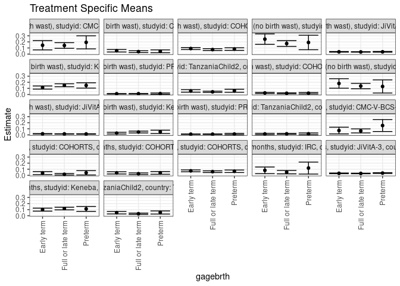

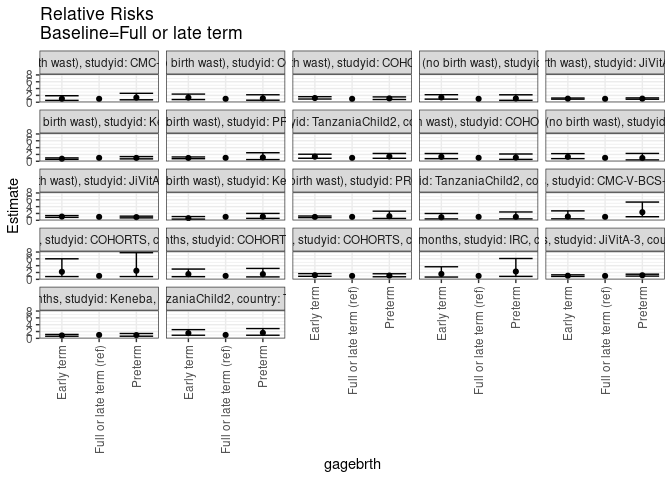

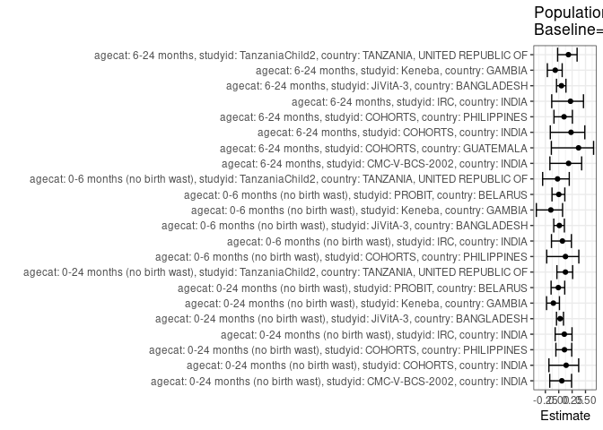

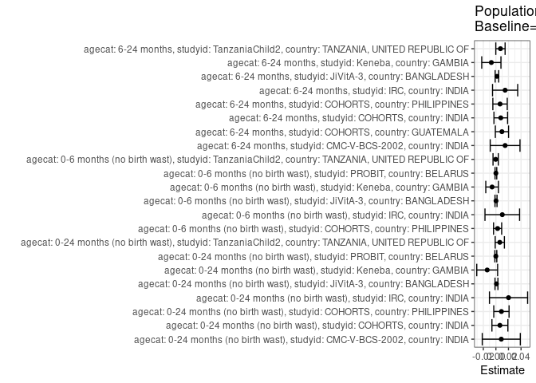

## Results Table

### Parameter: TSM

| agecat | studyid | country | intervention_level | baseline_level | estimate | ci_lower | ci_upper |
| --- | --- | --- | --- | --- | --- | --- | --- |
| 0-24 months (no birth wast) | CMC-V-BCS-2002 | INDIA | Full or late term | NA | 0.1408451 | 0.0940619 | 0.1876283 |
| 0-24 months (no birth wast) | CMC-V-BCS-2002 | INDIA | Preterm | NA | 0.1923077 | 0.0850342 | 0.2995812 |
| 0-24 months (no birth wast) | CMC-V-BCS-2002 | INDIA | Early term | NA | 0.1445783 | 0.0688121 | 0.2203445 |
| 0-24 months (no birth wast) | COHORTS | INDIA | Full or late term | NA | 0.0397237 | 0.0238092 | 0.0556382 |
| 0-24 months (no birth wast) | COHORTS | INDIA | Preterm | NA | 0.0454545 | 0.0221832 | 0.0687259 |
| 0-24 months (no birth wast) | COHORTS | INDIA | Early term | NA | 0.0545852 | 0.0337726 | 0.0753977 |
| 0-24 months (no birth wast) | COHORTS | PHILIPPINES | Full or late term | NA | 0.0734024 | 0.0583791 | 0.0884258 |
| 0-24 months (no birth wast) | COHORTS | PHILIPPINES | Preterm | NA | 0.0821485 | 0.0607539 | 0.1035431 |
| 0-24 months (no birth wast) | COHORTS | PHILIPPINES | Early term | NA | 0.0906822 | 0.0744459 | 0.1069185 |
| 0-24 months (no birth wast) | IRC | INDIA | Full or late term | NA | 0.1726908 | 0.1256823 | 0.2196992 |
| 0-24 months (no birth wast) | IRC | INDIA | Preterm | NA | 0.1904762 | 0.0715664 | 0.3093860 |
| 0-24 months (no birth wast) | IRC | INDIA | Early term | NA | 0.2448980 | 0.1596489 | 0.3301470 |
| 0-24 months (no birth wast) | JiVitA-3 | BANGLADESH | Full or late term | NA | 0.0347952 | 0.0313048 | 0.0382855 |
| 0-24 months (no birth wast) | JiVitA-3 | BANGLADESH | Preterm | NA | 0.0367762 | 0.0312520 | 0.0423005 |
| 0-24 months (no birth wast) | JiVitA-3 | BANGLADESH | Early term | NA | 0.0366097 | 0.0317456 | 0.0414737 |
| 0-24 months (no birth wast) | Keneba | GAMBIA | Full or late term | NA | 0.1515513 | 0.1272658 | 0.1758368 |
| 0-24 months (no birth wast) | Keneba | GAMBIA | Preterm | NA | 0.1484375 | 0.1048726 | 0.1920024 |
| 0-24 months (no birth wast) | Keneba | GAMBIA | Early term | NA | 0.1137124 | 0.0882607 | 0.1391641 |
| 0-24 months (no birth wast) | PROBIT | BELARUS | Full or late term | NA | 0.0121796 | 0.0079391 | 0.0164200 |
| 0-24 months (no birth wast) | PROBIT | BELARUS | Preterm | NA | 0.0135364 | 0.0026530 | 0.0244198 |
| 0-24 months (no birth wast) | PROBIT | BELARUS | Early term | NA | 0.0118690 | 0.0079340 | 0.0158041 |
| 0-24 months (no birth wast) | TanzaniaChild2 | TANZANIA, UNITED REPUBLIC OF | Full or late term | NA | 0.0433213 | 0.0325974 | 0.0540452 |
| 0-24 months (no birth wast) | TanzaniaChild2 | TANZANIA, UNITED REPUBLIC OF | Preterm | NA | 0.0610465 | 0.0357408 | 0.0863522 |
| 0-24 months (no birth wast) | TanzaniaChild2 | TANZANIA, UNITED REPUBLIC OF | Early term | NA | 0.0584795 | 0.0381699 | 0.0787892 |
| 0-6 months (no birth wast) | COHORTS | PHILIPPINES | Full or late term | NA | 0.0191304 | 0.0112120 | 0.0270489 |
| 0-6 months (no birth wast) | COHORTS | PHILIPPINES | Preterm | NA | 0.0206677 | 0.0095477 | 0.0317878 |
| 0-6 months (no birth wast) | COHORTS | PHILIPPINES | Early term | NA | 0.0251467 | 0.0162606 | 0.0340328 |
| 0-6 months (no birth wast) | IRC | INDIA | Full or late term | NA | 0.1380753 | 0.0942800 | 0.1818707 |
| 0-6 months (no birth wast) | IRC | INDIA | Preterm | NA | 0.1315789 | 0.0239570 | 0.2392009 |
| 0-6 months (no birth wast) | IRC | INDIA | Early term | NA | 0.1808511 | 0.1029377 | 0.2587645 |
| 0-6 months (no birth wast) | JiVitA-3 | BANGLADESH | Full or late term | NA | 0.0162283 | 0.0137461 | 0.0187105 |
| 0-6 months (no birth wast) | JiVitA-3 | BANGLADESH | Preterm | NA | 0.0150943 | 0.0115262 | 0.0186625 |
| 0-6 months (no birth wast) | JiVitA-3 | BANGLADESH | Early term | NA | 0.0177029 | 0.0143130 | 0.0210929 |
| 0-6 months (no birth wast) | Keneba | GAMBIA | Full or late term | NA | 0.0469361 | 0.0319633 | 0.0619089 |
| 0-6 months (no birth wast) | Keneba | GAMBIA | Preterm | NA | 0.0500000 | 0.0224179 | 0.0775821 |
| 0-6 months (no birth wast) | Keneba | GAMBIA | Early term | NA | 0.0286738 | 0.0148224 | 0.0425253 |
| 0-6 months (no birth wast) | PROBIT | BELARUS | Full or late term | NA | 0.0114902 | 0.0071987 | 0.0157818 |
| 0-6 months (no birth wast) | PROBIT | BELARUS | Preterm | NA | 0.0137694 | 0.0027531 | 0.0247857 |
| 0-6 months (no birth wast) | PROBIT | BELARUS | Early term | NA | 0.0113412 | 0.0076534 | 0.0150290 |
| 0-6 months (no birth wast) | TanzaniaChild2 | TANZANIA, UNITED REPUBLIC OF | Full or late term | NA | 0.0173913 | 0.0104927 | 0.0242899 |
| 0-6 months (no birth wast) | TanzaniaChild2 | TANZANIA, UNITED REPUBLIC OF | Preterm | NA | 0.0174927 | 0.0036157 | 0.0313697 |
| 0-6 months (no birth wast) | TanzaniaChild2 | TANZANIA, UNITED REPUBLIC OF | Early term | NA | 0.0156556 | 0.0048899 | 0.0264213 |
| 6-24 months | CMC-V-BCS-2002 | INDIA | Full or late term | NA | 0.0651163 | 0.0320891 | 0.0981435 |
| 6-24 months | CMC-V-BCS-2002 | INDIA | Preterm | NA | 0.1538462 | 0.0556411 | 0.2520512 |
| 6-24 months | CMC-V-BCS-2002 | INDIA | Early term | NA | 0.0714286 | 0.0162753 | 0.1265819 |
| 6-24 months | COHORTS | GUATEMALA | Full or late term | NA | 0.0163934 | 0.0043413 | 0.0284455 |
| 6-24 months | COHORTS | GUATEMALA | Preterm | NA | 0.0413223 | 0.0058355 | 0.0768091 |
| 6-24 months | COHORTS | GUATEMALA | Early term | NA | 0.0361991 | 0.0115570 | 0.0608412 |
| 6-24 months | COHORTS | INDIA | Full or late term | NA | 0.0261324 | 0.0130768 | 0.0391880 |
| 6-24 months | COHORTS | INDIA | Preterm | NA | 0.0396040 | 0.0176362 | 0.0615717 |
| 6-24 months | COHORTS | INDIA | Early term | NA | 0.0400000 | 0.0218878 | 0.0581122 |
| 6-24 months | COHORTS | PHILIPPINES | Full or late term | NA | 0.0601295 | 0.0459556 | 0.0743035 |
| 6-24 months | COHORTS | PHILIPPINES | Preterm | NA | 0.0665529 | 0.0463690 | 0.0867368 |
| 6-24 months | COHORTS | PHILIPPINES | Early term | NA | 0.0732143 | 0.0579560 | 0.0884725 |
| 6-24 months | IRC | INDIA | Full or late term | NA | 0.0520000 | 0.0244424 | 0.0795576 |
| 6-24 months | IRC | INDIA | Preterm | NA | 0.1190476 | 0.0209818 | 0.2171134 |
| 6-24 months | IRC | INDIA | Early term | NA | 0.0816327 | 0.0273535 | 0.1359118 |
| 6-24 months | JiVitA-3 | BANGLADESH | Full or late term | NA | 0.0306041 | 0.0264164 | 0.0347918 |
| 6-24 months | JiVitA-3 | BANGLADESH | Preterm | NA | 0.0364155 | 0.0294163 | 0.0434146 |
| 6-24 months | JiVitA-3 | BANGLADESH | Early term | NA | 0.0324419 | 0.0269165 | 0.0379674 |
| 6-24 months | Keneba | GAMBIA | Full or late term | NA | 0.1179361 | 0.0957724 | 0.1400998 |
| 6-24 months | Keneba | GAMBIA | Preterm | NA | 0.1120332 | 0.0722001 | 0.1518663 |
| 6-24 months | Keneba | GAMBIA | Early term | NA | 0.1000000 | 0.0755776 | 0.1244224 |
| 6-24 months | TanzaniaChild2 | TANZANIA, UNITED REPUBLIC OF | Full or late term | NA | 0.0328152 | 0.0225516 | 0.0430788 |
| 6-24 months | TanzaniaChild2 | TANZANIA, UNITED REPUBLIC OF | Preterm | NA | 0.0533333 | 0.0279002 | 0.0787665 |
| 6-24 months | TanzaniaChild2 | TANZANIA, UNITED REPUBLIC OF | Early term | NA | 0.0501139 | 0.0296991 | 0.0705287 |

### Parameter: E(Y)

| agecat | studyid | country | intervention_level | baseline_level | estimate | ci_lower | ci_upper |
| --- | --- | --- | --- | --- | --- | --- | --- |
| 0-24 months (no birth wast) | CMC-V-BCS-2002 | INDIA | NA | NA | 0.1494253 | 0.1119149 | 0.1869357 |
| 0-24 months (no birth wast) | COHORTS | INDIA | NA | NA | 0.0460967 | 0.0348859 | 0.0573074 |
| 0-24 months (no birth wast) | COHORTS | PHILIPPINES | NA | NA | 0.0821918 | 0.0723504 | 0.0920332 |
| 0-24 months (no birth wast) | IRC | INDIA | NA | NA | 0.1928021 | 0.1535486 | 0.2320555 |
| 0-24 months (no birth wast) | JiVitA-3 | BANGLADESH | NA | NA | 0.0357002 | 0.0330794 | 0.0383209 |
| 0-24 months (no birth wast) | Keneba | GAMBIA | NA | NA | 0.1377069 | 0.1212828 | 0.1541310 |
| 0-24 months (no birth wast) | PROBIT | BELARUS | NA | NA | 0.0120860 | 0.0083142 | 0.0158578 |
| 0-24 months (no birth wast) | TanzaniaChild2 | TANZANIA, UNITED REPUBLIC OF | NA | NA | 0.0495094 | 0.0405280 | 0.0584908 |
| 0-6 months (no birth wast) | COHORTS | PHILIPPINES | NA | NA | 0.0218708 | 0.0166115 | 0.0271301 |
| 0-6 months (no birth wast) | IRC | INDIA | NA | NA | 0.1482480 | 0.1120405 | 0.1844555 |
| 0-6 months (no birth wast) | JiVitA-3 | BANGLADESH | NA | NA | 0.0164098 | 0.0145698 | 0.0182498 |
| 0-6 months (no birth wast) | Keneba | GAMBIA | NA | NA | 0.0408946 | 0.0310794 | 0.0507097 |
| 0-6 months (no birth wast) | PROBIT | BELARUS | NA | NA | 0.0115018 | 0.0077384 | 0.0152653 |
| 0-6 months (no birth wast) | TanzaniaChild2 | TANZANIA, UNITED REPUBLIC OF | NA | NA | 0.0170098 | 0.0116466 | 0.0223731 |
| 6-24 months | CMC-V-BCS-2002 | INDIA | NA | NA | 0.0797721 | 0.0513872 | 0.1081570 |
| 6-24 months | COHORTS | GUATEMALA | NA | NA | 0.0260078 | 0.0147515 | 0.0372641 |
| 6-24 months | COHORTS | INDIA | NA | NA | 0.0339111 | 0.0241689 | 0.0436532 |
| 6-24 months | COHORTS | PHILIPPINES | NA | NA | 0.0667384 | 0.0574713 | 0.0760056 |
| 6-24 months | IRC | INDIA | NA | NA | 0.0666667 | 0.0418784 | 0.0914549 |
| 6-24 months | JiVitA-3 | BANGLADESH | NA | NA | 0.0322267 | 0.0291993 | 0.0352542 |
| 6-24 months | Keneba | GAMBIA | NA | NA | 0.1107034 | 0.0954900 | 0.1259167 |
| 6-24 months | TanzaniaChild2 | TANZANIA, UNITED REPUBLIC OF | NA | NA | 0.0400633 | 0.0312360 | 0.0488905 |

### Parameter: RR

| agecat | studyid | country | intervention_level | baseline_level | estimate | ci_lower | ci_upper |
| --- | --- | --- | --- | --- | --- | --- | --- |
| 0-24 months (no birth wast) | CMC-V-BCS-2002 | INDIA | Full or late term | Full or late term | 1.0000000 | 1.0000000 | 1.0000000 |
| 0-24 months (no birth wast) | CMC-V-BCS-2002 | INDIA | Preterm | Full or late term | 1.3653846 | 0.7133440 | 2.6134306 |
| 0-24 months (no birth wast) | CMC-V-BCS-2002 | INDIA | Early term | Full or late term | 1.0265060 | 0.5519545 | 1.9090606 |
| 0-24 months (no birth wast) | COHORTS | INDIA | Full or late term | Full or late term | 1.0000000 | 1.0000000 | 1.0000000 |
| 0-24 months (no birth wast) | COHORTS | INDIA | Preterm | Full or late term | 1.1442688 | 0.5973068 | 2.1920911 |
| 0-24 months (no birth wast) | COHORTS | INDIA | Early term | Full or late term | 1.3741219 | 0.7903712 | 2.3890179 |
| 0-24 months (no birth wast) | COHORTS | PHILIPPINES | Full or late term | Full or late term | 1.0000000 | 1.0000000 | 1.0000000 |
| 0-24 months (no birth wast) | COHORTS | PHILIPPINES | Preterm | Full or late term | 1.1191525 | 0.8035899 | 1.5586336 |
| 0-24 months (no birth wast) | COHORTS | PHILIPPINES | Early term | Full or late term | 1.2354116 | 0.9412661 | 1.6214775 |
| 0-24 months (no birth wast) | IRC | INDIA | Full or late term | Full or late term | 1.0000000 | 1.0000000 | 1.0000000 |
| 0-24 months (no birth wast) | IRC | INDIA | Preterm | Full or late term | 1.1029900 | 0.5582108 | 2.1794403 |
| 0-24 months (no birth wast) | IRC | INDIA | Early term | Full or late term | 1.4181300 | 0.9115965 | 2.2061217 |
| 0-24 months (no birth wast) | JiVitA-3 | BANGLADESH | Full or late term | Full or late term | 1.0000000 | 1.0000000 | 1.0000000 |
| 0-24 months (no birth wast) | JiVitA-3 | BANGLADESH | Preterm | Full or late term | 1.0569339 | 0.8872893 | 1.2590135 |
| 0-24 months (no birth wast) | JiVitA-3 | BANGLADESH | Early term | Full or late term | 1.0521480 | 0.8942062 | 1.2379866 |
| 0-24 months (no birth wast) | Keneba | GAMBIA | Full or late term | Full or late term | 1.0000000 | 1.0000000 | 1.0000000 |
| 0-24 months (no birth wast) | Keneba | GAMBIA | Preterm | Full or late term | 0.9794537 | 0.7010698 | 1.3683796 |
| 0-24 months (no birth wast) | Keneba | GAMBIA | Early term | Full or late term | 0.7503226 | 0.5697671 | 0.9880949 |
| 0-24 months (no birth wast) | PROBIT | BELARUS | Full or late term | Full or late term | 1.0000000 | 1.0000000 | 1.0000000 |
| 0-24 months (no birth wast) | PROBIT | BELARUS | Preterm | Full or late term | 1.1114012 | 0.4942436 | 2.4991981 |
| 0-24 months (no birth wast) | PROBIT | BELARUS | Early term | Full or late term | 0.9745055 | 0.7534443 | 1.2604262 |
| 0-24 months (no birth wast) | TanzaniaChild2 | TANZANIA, UNITED REPUBLIC OF | Full or late term | Full or late term | 1.0000000 | 1.0000000 | 1.0000000 |
| 0-24 months (no birth wast) | TanzaniaChild2 | TANZANIA, UNITED REPUBLIC OF | Preterm | Full or late term | 1.4091570 | 0.8695083 | 2.2837314 |
| 0-24 months (no birth wast) | TanzaniaChild2 | TANZANIA, UNITED REPUBLIC OF | Early term | Full or late term | 1.3499025 | 0.8812130 | 2.0678732 |
| 0-6 months (no birth wast) | COHORTS | PHILIPPINES | Full or late term | Full or late term | 1.0000000 | 1.0000000 | 1.0000000 |
| 0-6 months (no birth wast) | COHORTS | PHILIPPINES | Preterm | Full or late term | 1.0803584 | 0.5479663 | 2.1300110 |
| 0-6 months (no birth wast) | COHORTS | PHILIPPINES | Early term | Full or late term | 1.3144860 | 0.7627717 | 2.2652565 |
| 0-6 months (no birth wast) | IRC | INDIA | Full or late term | Full or late term | 1.0000000 | 1.0000000 | 1.0000000 |
| 0-6 months (no birth wast) | IRC | INDIA | Preterm | Full or late term | 0.9529506 | 0.3963465 | 2.2912142 |
| 0-6 months (no birth wast) | IRC | INDIA | Early term | Full or late term | 1.3098001 | 0.7671220 | 2.2363800 |
| 0-6 months (no birth wast) | JiVitA-3 | BANGLADESH | Full or late term | Full or late term | 1.0000000 | 1.0000000 | 1.0000000 |
| 0-6 months (no birth wast) | JiVitA-3 | BANGLADESH | Preterm | Full or late term | 0.9301261 | 0.7119587 | 1.2151471 |
| 0-6 months (no birth wast) | JiVitA-3 | BANGLADESH | Early term | Full or late term | 1.0908700 | 0.8564750 | 1.3894130 |
| 0-6 months (no birth wast) | Keneba | GAMBIA | Full or late term | Full or late term | 1.0000000 | 1.0000000 | 1.0000000 |
| 0-6 months (no birth wast) | Keneba | GAMBIA | Preterm | Full or late term | 1.0652778 | 0.5632659 | 2.0147089 |
| 0-6 months (no birth wast) | Keneba | GAMBIA | Early term | Full or late term | 0.6109120 | 0.3424267 | 1.0899076 |
| 0-6 months (no birth wast) | PROBIT | BELARUS | Full or late term | Full or late term | 1.0000000 | 1.0000000 | 1.0000000 |
| 0-6 months (no birth wast) | PROBIT | BELARUS | Preterm | Full or late term | 1.1983561 | 0.5365041 | 2.6766942 |
| 0-6 months (no birth wast) | PROBIT | BELARUS | Early term | Full or late term | 0.9870279 | 0.7773190 | 1.2533132 |
| 0-6 months (no birth wast) | TanzaniaChild2 | TANZANIA, UNITED REPUBLIC OF | Full or late term | Full or late term | 1.0000000 | 1.0000000 | 1.0000000 |
| 0-6 months (no birth wast) | TanzaniaChild2 | TANZANIA, UNITED REPUBLIC OF | Preterm | Full or late term | 1.0058309 | 0.4143137 | 2.4418593 |
| 0-6 months (no birth wast) | TanzaniaChild2 | TANZANIA, UNITED REPUBLIC OF | Early term | Full or late term | 0.9001957 | 0.4069725 | 1.9911720 |
| 6-24 months | CMC-V-BCS-2002 | INDIA | Full or late term | Full or late term | 1.0000000 | 1.0000000 | 1.0000000 |
| 6-24 months | CMC-V-BCS-2002 | INDIA | Preterm | Full or late term | 2.3626374 | 1.0454758 | 5.3392488 |
| 6-24 months | CMC-V-BCS-2002 | INDIA | Early term | Full or late term | 1.0969388 | 0.4354790 | 2.7631061 |
| 6-24 months | COHORTS | GUATEMALA | Full or late term | Full or late term | 1.0000000 | 1.0000000 | 1.0000000 |
| 6-24 months | COHORTS | GUATEMALA | Preterm | Full or late term | 2.5206612 | 0.8138650 | 7.8068629 |
| 6-24 months | COHORTS | GUATEMALA | Early term | Full or late term | 2.2081448 | 0.8107545 | 6.0140317 |
| 6-24 months | COHORTS | INDIA | Full or late term | Full or late term | 1.0000000 | 1.0000000 | 1.0000000 |
| 6-24 months | COHORTS | INDIA | Preterm | Full or late term | 1.5155116 | 0.7183840 | 3.1971413 |
| 6-24 months | COHORTS | INDIA | Early term | Full or late term | 1.5306667 | 0.7799265 | 3.0040530 |
| 6-24 months | COHORTS | PHILIPPINES | Full or late term | Full or late term | 1.0000000 | 1.0000000 | 1.0000000 |
| 6-24 months | COHORTS | PHILIPPINES | Preterm | Full or late term | 1.1068259 | 0.7538093 | 1.6251639 |
| 6-24 months | COHORTS | PHILIPPINES | Early term | Full or late term | 1.2176099 | 0.8889179 | 1.6678411 |
| 6-24 months | IRC | INDIA | Full or late term | Full or late term | 1.0000000 | 1.0000000 | 1.0000000 |
| 6-24 months | IRC | INDIA | Preterm | Full or late term | 2.2893773 | 0.8596588 | 6.0968941 |
| 6-24 months | IRC | INDIA | Early term | Full or late term | 1.5698587 | 0.6707962 | 3.6739273 |
| 6-24 months | JiVitA-3 | BANGLADESH | Full or late term | Full or late term | 1.0000000 | 1.0000000 | 1.0000000 |
| 6-24 months | JiVitA-3 | BANGLADESH | Preterm | Full or late term | 1.1898885 | 0.9436490 | 1.5003828 |
| 6-24 months | JiVitA-3 | BANGLADESH | Early term | Full or late term | 1.0600516 | 0.8495396 | 1.3227274 |
| 6-24 months | Keneba | GAMBIA | Full or late term | Full or late term | 1.0000000 | 1.0000000 | 1.0000000 |
| 6-24 months | Keneba | GAMBIA | Preterm | Full or late term | 0.9499481 | 0.6353963 | 1.4202183 |
| 6-24 months | Keneba | GAMBIA | Early term | Full or late term | 0.8479167 | 0.6230469 | 1.1539462 |
| 6-24 months | TanzaniaChild2 | TANZANIA, UNITED REPUBLIC OF | Full or late term | Full or late term | 1.0000000 | 1.0000000 | 1.0000000 |
| 6-24 months | TanzaniaChild2 | TANZANIA, UNITED REPUBLIC OF | Preterm | Full or late term | 1.6252632 | 0.9188605 | 2.8747348 |
| 6-24 months | TanzaniaChild2 | TANZANIA, UNITED REPUBLIC OF | Early term | Full or late term | 1.5271550 | 0.9137641 | 2.5523025 |

### Parameter: PAR

| agecat | studyid | country | intervention_level | baseline_level | estimate | ci_lower | ci_upper |
| --- | --- | --- | --- | --- | --- | --- | --- |
| 0-24 months (no birth wast) | CMC-V-BCS-2002 | INDIA | Full or late term | NA | 0.0085802 | -0.0216930 | 0.0388534 |
| 0-24 months (no birth wast) | COHORTS | INDIA | Full or late term | NA | 0.0063730 | -0.0063114 | 0.0190574 |
| 0-24 months (no birth wast) | COHORTS | PHILIPPINES | Full or late term | NA | 0.0087894 | -0.0033723 | 0.0209510 |
| 0-24 months (no birth wast) | IRC | INDIA | Full or late term | NA | 0.0201113 | -0.0102472 | 0.0504698 |
| 0-24 months (no birth wast) | JiVitA-3 | BANGLADESH | Full or late term | NA | 0.0009050 | -0.0014216 | 0.0032315 |
| 0-24 months (no birth wast) | Keneba | GAMBIA | Full or late term | NA | -0.0138445 | -0.0304375 | 0.0027486 |
| 0-24 months (no birth wast) | PROBIT | BELARUS | Full or late term | NA | -0.0000935 | -0.0016320 | 0.0014449 |
| 0-24 months (no birth wast) | TanzaniaChild2 | TANZANIA, UNITED REPUBLIC OF | Full or late term | NA | 0.0061881 | -0.0011319 | 0.0135081 |
| 0-6 months (no birth wast) | COHORTS | PHILIPPINES | Full or late term | NA | 0.0027404 | -0.0037278 | 0.0092086 |
| 0-6 months (no birth wast) | IRC | INDIA | Full or late term | NA | 0.0101727 | -0.0173555 | 0.0377009 |
| 0-6 months (no birth wast) | JiVitA-3 | BANGLADESH | Full or late term | NA | 0.0001816 | -0.0014400 | 0.0018031 |
| 0-6 months (no birth wast) | Keneba | GAMBIA | Full or late term | NA | -0.0060415 | -0.0160803 | 0.0039972 |
| 0-6 months (no birth wast) | PROBIT | BELARUS | Full or late term | NA | 0.0000116 | -0.0013615 | 0.0013847 |
| 0-6 months (no birth wast) | TanzaniaChild2 | TANZANIA, UNITED REPUBLIC OF | Full or late term | NA | -0.0003815 | -0.0045718 | 0.0038089 |
| 6-24 months | CMC-V-BCS-2002 | INDIA | Full or late term | NA | 0.0146558 | -0.0090126 | 0.0383242 |
| 6-24 months | COHORTS | GUATEMALA | Full or late term | NA | 0.0096144 | -0.0009047 | 0.0201334 |
| 6-24 months | COHORTS | INDIA | Full or late term | NA | 0.0077787 | -0.0030796 | 0.0186369 |
| 6-24 months | COHORTS | PHILIPPINES | Full or late term | NA | 0.0066089 | -0.0048337 | 0.0180515 |
| 6-24 months | IRC | INDIA | Full or late term | NA | 0.0146667 | -0.0053399 | 0.0346732 |
| 6-24 months | JiVitA-3 | BANGLADESH | Full or late term | NA | 0.0016227 | -0.0012046 | 0.0044499 |
| 6-24 months | Keneba | GAMBIA | Full or late term | NA | -0.0072328 | -0.0225151 | 0.0080496 |
| 6-24 months | TanzaniaChild2 | TANZANIA, UNITED REPUBLIC OF | Full or late term | NA | 0.0072481 | -0.0001447 | 0.0146408 |

### Parameter: PAF

| agecat | studyid | country | intervention_level | baseline_level | estimate | ci_lower | ci_upper |
| --- | --- | --- | --- | --- | --- | --- | --- |
| 0-24 months (no birth wast) | CMC-V-BCS-2002 | INDIA | Full or late term | NA | 0.0574215 | -0.1681713 | 0.2394486 |
| 0-24 months (no birth wast) | COHORTS | INDIA | Full or late term | NA | 0.1382528 | -0.1833274 | 0.3724407 |
| 0-24 months (no birth wast) | COHORTS | PHILIPPINES | Full or late term | NA | 0.1069372 | -0.0534434 | 0.2429009 |
| 0-24 months (no birth wast) | IRC | INDIA | Full or late term | NA | 0.1043106 | -0.0668583 | 0.2480168 |
| 0-24 months (no birth wast) | JiVitA-3 | BANGLADESH | Full or late term | NA | 0.0253490 | -0.0420604 | 0.0883977 |
| 0-24 months (no birth wast) | Keneba | GAMBIA | Full or late term | NA | -0.1005357 | -0.2274425 | 0.0132500 |
| 0-24 months (no birth wast) | PROBIT | BELARUS | Full or late term | NA | -0.0077393 | -0.1431149 | 0.1116042 |
| 0-24 months (no birth wast) | TanzaniaChild2 | TANZANIA, UNITED REPUBLIC OF | Full or late term | NA | 0.1249878 | -0.0342088 | 0.2596792 |
| 0-6 months (no birth wast) | COHORTS | PHILIPPINES | Full or late term | NA | 0.1252977 | -0.2245199 | 0.3751803 |
| 0-6 months (no birth wast) | IRC | INDIA | Full or late term | NA | 0.0686192 | -0.1362511 | 0.2365507 |
| 0-6 months (no birth wast) | JiVitA-3 | BANGLADESH | Full or late term | NA | 0.0110649 | -0.0928989 | 0.1051390 |
| 0-6 months (no birth wast) | Keneba | GAMBIA | Full or late term | NA | -0.1477347 | -0.4185707 | 0.0713929 |
| 0-6 months (no birth wast) | PROBIT | BELARUS | Full or late term | NA | 0.0010100 | -0.1258804 | 0.1135995 |
| 0-6 months (no birth wast) | TanzaniaChild2 | TANZANIA, UNITED REPUBLIC OF | Full or late term | NA | -0.0224256 | -0.3008630 | 0.1964149 |
| 6-24 months | CMC-V-BCS-2002 | INDIA | Full or late term | NA | 0.1837209 | -0.1651221 | 0.4281187 |
| 6-24 months | COHORTS | GUATEMALA | Full or late term | NA | 0.3696721 | -0.1384210 | 0.6509962 |
| 6-24 months | COHORTS | INDIA | Full or late term | NA | 0.2293844 | -0.1578152 | 0.4870957 |
| 6-24 months | COHORTS | PHILIPPINES | Full or late term | NA | 0.0990272 | -0.0892458 | 0.2547577 |
| 6-24 months | IRC | INDIA | Full or late term | NA | 0.2200000 | -0.1312945 | 0.4622090 |
| 6-24 months | JiVitA-3 | BANGLADESH | Full or late term | NA | 0.0503511 | -0.0418139 | 0.1343627 |
| 6-24 months | Keneba | GAMBIA | Full or late term | NA | -0.0653345 | -0.2124813 | 0.0639545 |
| 6-24 months | TanzaniaChild2 | TANZANIA, UNITED REPUBLIC OF | Full or late term | NA | 0.1809154 | -0.0209810 | 0.3428872 |